# R-Lab: Dimension Reduction

First apply random forests to the data set. The importance scores of variables are be plotted below. The variable names are ommitted due to limited space. This chart provide a ranking of all variables in terms of predictive power, and the top variables are ST62TA, ST59TS, ST56TA, ST58CV and ST26TS. However, a large number of variables have non-zero importane scores, and if we use a threshold to select a variable subset, there may be redundant variables selected.

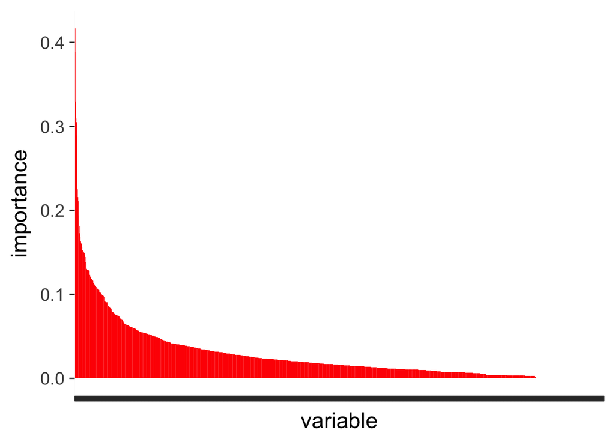

```r
require(dplyr)
require(tidyr)
require(inTrees)
require(ggplot2)
require(randomForest)
require(RRF)
require(RCurl)
set.seed(1)
theme_set(theme_gray(base_size = 18))


data <- read.csv(text = getURL("https://raw.githubusercontent.com/shuailab/ind_498/master/resource/data/AD_hd.csv"))
data$AGE <- as.factor(dicretizeVector(data$AGE, K = 2))
target <- data$AGE
rm_indx <- which(colnames(data) %in% c("AGE", "ID", "TOTAL13", "MMSCORE"))
X <- data[, -rm_indx]
X1 <- cbind(X, X, X)
colnames(X1) <- paste0("Y", 1:ncol(X1))
for (i in 1:ncol(X1)) {
    perc <- 0.1
    index <- sample(nrow(X1), floor(nrow(X1) * perc))
    X1[, i][sort(index)] <- (X1[, i])[index]
}
X <- cbind(X, X1)

rf <- randomForest(X, target)

imp <- as.data.frame(rf$importance)
colnames(imp)[colnames(imp) == "MeanDecreaseGini"] <- "importance"
imp <- imp[order(imp$importance, decreasing = TRUE), , drop = FALSE]
imp$variable <- rownames(imp)
imp$variable <- factor(imp$variable, levels = as.character(imp$variable))
ggplot(data = imp, aes(x = variable, y = importance)) + geom_bar(stat = "identity",
    aes(factor(variable)), fill = "red") + theme(axis.text.x = element_blank())
```

Now apply the regularized random forests to the data. The importance scores from the RRF are plotted below. Clearly a much smaller number of variables have non-zero importance scores, compared to ordinary random forests.

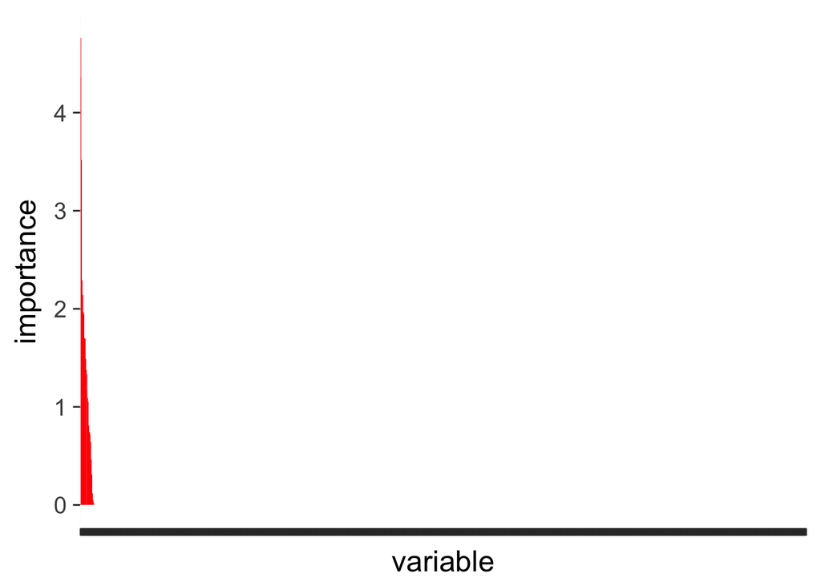

```r
rrf <- RRF(X, target)
imp <- as.data.frame(rrf$importance)
colnames(imp)[colnames(imp) == "MeanDecreaseGini"] <- "importance"
imp <- imp[order(imp$importance, decreasing = TRUE), , drop = FALSE]
imp$variable <- rownames(imp)
imp$variable <- factor(imp$variable, levels = as.character(imp$variable))
ggplot(data = imp, aes(x = variable, y = importance)) + geom_bar(stat = "identity",
    aes(factor(variable)), fill = "red") + theme(axis.text.x = element_blank())
```

Now apply the guided regularized random forests to the data. The importance scores from the GRRF are plotted below. Similarly the number of variables with non-zero importance scores is much smaller than ordinary random forests.

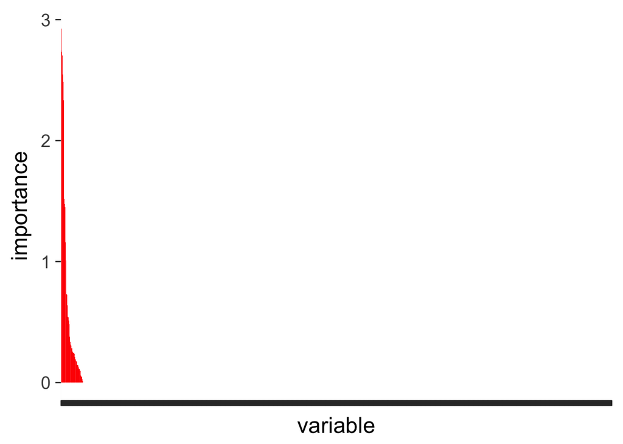

```r
rf <- randomForest(X, target)
impRF <- rf$importance
impRF <- impRF[, "MeanDecreaseGini"]
imp <- impRF/(max(impRF))  #normalize the importance scores into [0,1]
gamma <- 0.1
coefReg <- (1 - gamma) * 1 + gamma * imp  # each variable has a coefficient, which depends on the importance score from the ordinary RF and the parameter: gamma
grrf <- RRF(X, target, flagReg = 1, coefReg = coefReg)

imp <- as.data.frame(grrf$importance)
colnames(imp)[colnames(imp) == "MeanDecreaseGini"] <- "importance"
imp <- imp[order(imp$importance, decreasing = TRUE), , drop = FALSE]
imp$variable <- rownames(imp)
imp$variable <- factor(imp$variable, levels = as.character(imp$variable))
ggplot(data = imp, aes(x = variable, y = importance)) + geom_bar(stat = "identity",
    aes(factor(variable)), fill = "red") + theme(axis.text.x = element_blank())
```

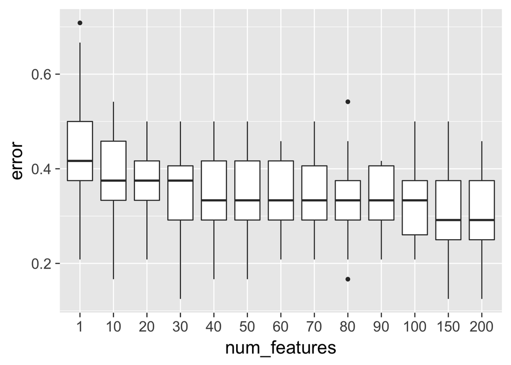

```r
set.seed(1)
testing.indices <- NULL
for (i in 1:50) {
    testing.indices <- rbind(testing.indices, sample(nrow(data), floor(1 * nrow(data)/3)))
}

err.mat.rf <- NULL
for (K in c(1, (1:10) * 10, 150, 200)) {
    pred <- NULL
    for (i in 1:nrow(testing.indices)) {

        testing.ix <- testing.indices[i, ]
        X.training <- X[-testing.ix, ]
        target.training <- target[-testing.ix]
        X.testing <- X[testing.ix, , drop = FALSE]
        target.testing <- target[testing.ix]

        rf <- randomForest(X.training, target.training)
        impRF <- rf$importance
        impRF <- impRF[, "MeanDecreaseGini"]
        ix <- order(impRF, decreasing = TRUE)

        X.training.new <- X.training[, ix[1:K], drop = FALSE]
        rf <- randomForest(X.training.new, target.training)

        target.pred <- predict(rf, X.testing)
        # pred <- c(pred, as.character(target.pred) )

        error <- length(which(as.character(target.pred) != target.testing))/length(target.testing)
        err.mat.rf <- rbind(err.mat.rf, c(K, error))
    }
    # error <- length(which(pred != target))/length(pred) err.mat.rf <-
    # rbind(err.mat.rf, c(K,error))
}
err.mat.rf <- as.data.frame(err.mat.rf)
colnames(err.mat.rf) <- c("num_features", "error")

# err.mat.rf$num_features <- factor( err.mat.rf$num_features , unique(
# err.mat.rf$num_features ) )
ggplot() + geom_boxplot(data = err.mat.rf %>% mutate(num_features = as.factor(num_features)),
    aes(y = error, x = num_features)) + geom_point(size = 3)
```

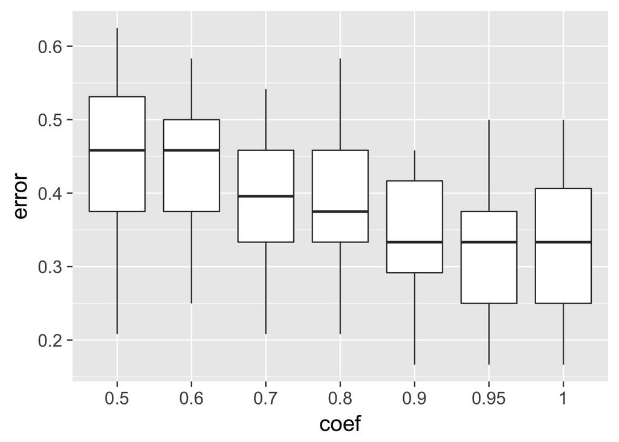

```r
set.seed(1)
err.mat.rrf <- NULL
for (coefI in c(0.5, 0.6, 0.7, 0.8, 0.9, 0.95, 1)) {
    pred <- NULL
    for (i in 1:nrow(testing.indices)) {
        testing.ix <- testing.indices[i, ]
        X.training <- X[-testing.ix, ]
        target.training <- target[-testing.ix]
        X.testing <- X[testing.ix, , drop = FALSE]
        target.testing <- target[testing.ix]

        rrf <- RRF(X.training, target.training, coefReg = coefI)

        X.training.new <- X.training[, rrf$feaSet, drop = FALSE]
        rf <- randomForest(X.training.new, target.training)

        target.pred <- predict(rf, X.testing)
        # pred <- c(pred, as.character(target.pred) )
        error <- length(which(as.character(target.pred) != target.testing))/length(target.testing)
        err.mat.rrf <- rbind(err.mat.rrf, c(coefI, length(rrf$feaSet), error))
    }
    # error <- length(which(pred != target))/length(pred) err.mat.rrf <-
    # rbind(err.mat.rrf, c(coefI, mean(num.fea.v), error))
}
err.mat.rrf <- as.data.frame(err.mat.rrf)
colnames(err.mat.rrf) <- c("coef", "num_features", "error")
# err.mat.rrf <- err.mat.rrf %>% mutate(coef=as.factor(coef))
ggplot() + geom_boxplot(data = err.mat.rrf %>% mutate(coef = as.factor(coef)),
    aes(y = error, x = coef)) + geom_point(size = 3)
```

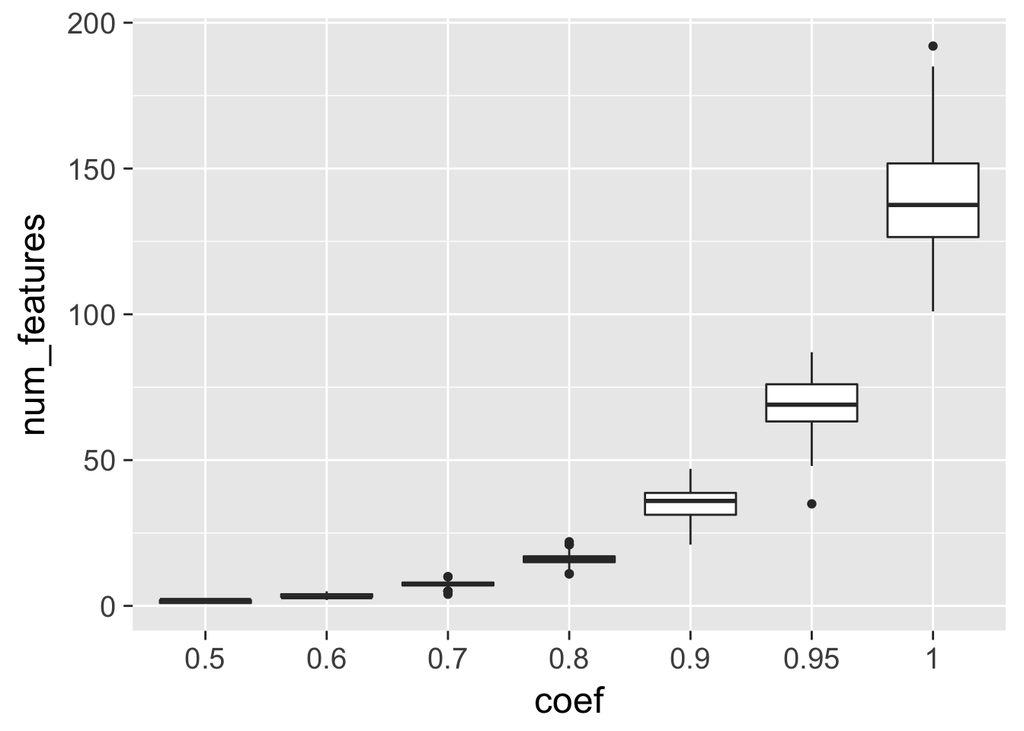

```r
ggplot() + geom_boxplot(data = err.mat.rrf %>% mutate(coef = as.factor(coef)),
    aes(y = num_features, x = coef)) + geom_point(size = 3)
```

Here we try differnet parameters on GRRF and check the number of features and error rates. The weights come from the importance scores from random forests.

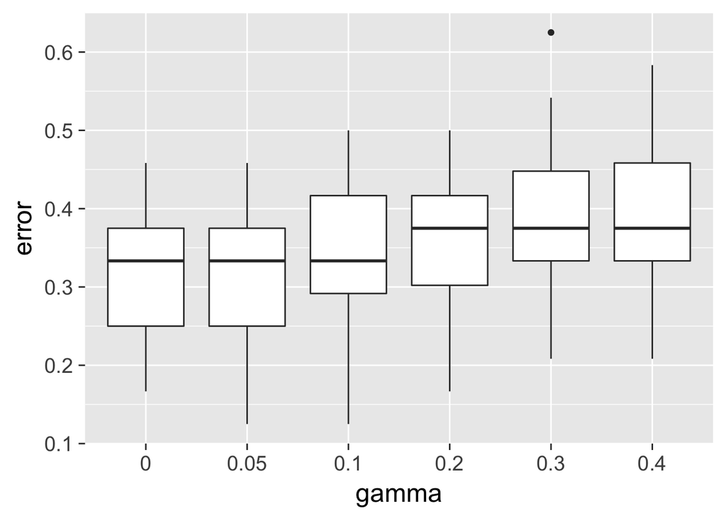

```r
set.seed(1)
err.mat.grrf <- NULL
for (gammaI in c(0.4, 0.3, 0.2, 0.1, 0.05, 0)) {
    pred <- NULL
    num.fea.v <- NULL

    for (i in 1:nrow(testing.indices)) {
        testing.ix <- testing.indices[i, ]
        X.training <- X[-testing.ix, ]
        target.training <- target[-testing.ix]
        X.testing <- X[testing.ix, , drop = FALSE]
        target.testing <- target[testing.ix]

        rf <- randomForest(X.training, target.training)
        impRF <- rf$importance
        impRF <- impRF[, "MeanDecreaseGini"]
        imp <- impRF/(max(impRF))
        coefReg <- (1 - gammaI) * 1 + gammaI * imp

        grrf <- RRF(X.training, target.training, flagReg = 1, coefReg = coefReg)

        # num.fea.v <- c(num.fea.v, length(grrf$feaSet))
        X.training.new <- X.training[, grrf$feaSet, drop = FALSE]

        rf <- randomForest(X.training.new, target.training)

        target.pred <- predict(rf, X.testing)
        # pred <- c(pred, as.character(target.pred) )
        error <- length(which(as.character(target.pred) != target.testing))/length(target.testing)
        err.mat.grrf <- rbind(err.mat.grrf, c(gammaI, length(grrf$feaSet), error))
    }
}

err.mat.grrf <- as.data.frame(err.mat.grrf)
colnames(err.mat.grrf) <- c("gamma", "num_features", "error")
# err.mat.grrf <- err.mat.grrf %>% mutate(gamma=as.factor(gamma))
ggplot() + geom_boxplot(data = err.mat.grrf %>% mutate(gamma = as.factor(gamma)),
    aes(y = error, x = gamma)) + geom_point(size = 3)
```

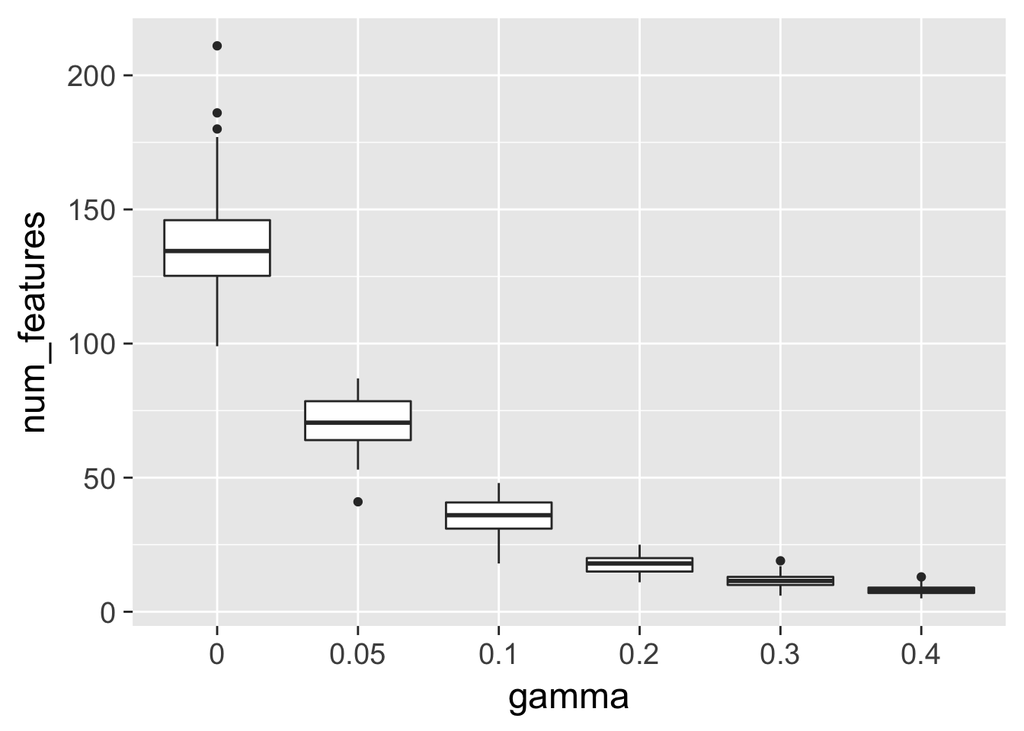

```r
ggplot() + geom_boxplot(data = err.mat.grrf %>% mutate(gamma = as.factor(gamma)),
    aes(y = num_features, x = gamma)) + geom_point(size = 3)
```

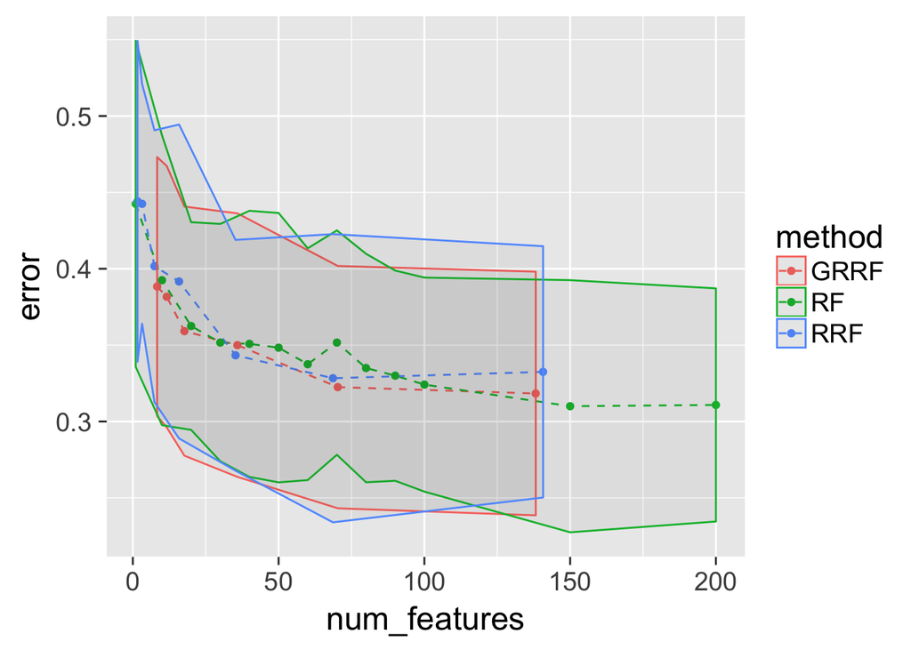

```r
err.mat.rf <- as.data.frame(err.mat.rf)
err.mat.rf$method <- "RF"

err.mat.rrf <- as.data.frame(err.mat.rrf)
err.mat.rrf$method <- "RRF"

err.mat.grrf <- as.data.frame(err.mat.grrf)
err.mat.grrf$method <- "GRRF"

err.mat.rrf.summary <- err.mat.rrf %>% group_by(coef, method) %>% summarize(num_features = mean(num_features),
    sd = sd(error), error = mean(error), upper = error + sd, lower = error -
        sd) %>% ungroup()
err.mat.grrf.summary <- err.mat.grrf %>% group_by(gamma, method) %>% summarize(num_features = mean(num_features),
    sd = sd(error), error = mean(error), upper = error + sd, lower = error -
        sd) %>% ungroup()
err.mat.rf.summary <- err.mat.rf %>% group_by(num_features, method) %>% summarize(sd = sd(error),
    error = mean(error), upper = error + sd, lower = error - sd) %>% ungroup()
err.mat <- rbind(err.mat.rf.summary[, c("num_features", "error", "method", "lower",
    "upper")], err.mat.rrf.summary[, c("num_features", "error", "method", "lower",
    "upper")], err.mat.grrf.summary[, c("num_features", "error", "method", "lower",
    "upper")])

# ggplot(err.mat, aes(x=num_features, y=error, fill=method)) +
# geom_boxplot(position=position_dodge(1))

ggplot(err.mat, aes(x = num_features, y = error, group = method, colour = method)) +
    geom_line(linetype = "dashed") + geom_point() + geom_ribbon(data = err.mat,
    aes(ymin = lower, ymax = upper), alpha = 0.05)
```

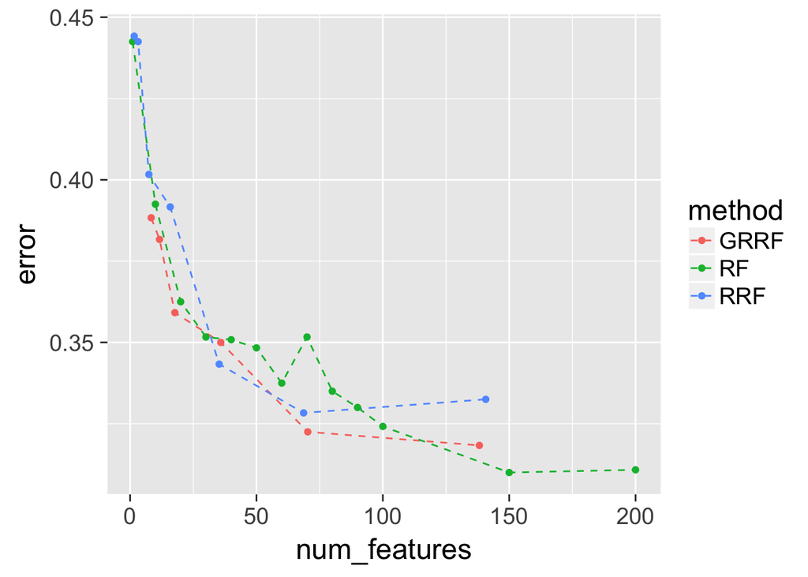

```r
ggplot(err.mat, aes(x = num_features, y = error, group = method, colour = method)) +
    geom_line(linetype = "dashed") + geom_point()
```

```r
# new.data <- err.mat %>% group_by(num_features,method) %>%
# summarize(sd=sd(error),error=median(error)) %>%
# #mutate(upper=error+sd,lower=error-sd) ggplot(new.data,
# aes(x=num_features, y=error, group=method, colour = method)) +
# geom_line(linetype = 'dashed')+ geom_point() + ylim(0,0.5) #
# geom_ribbon(data=new.data,aes(ymin=lower,ymax=upper),alpha=1)
```